# Biogeography Final Project

Devin Richards

2024-12-12

# Introduction:

The goal of this project is to investigate the well documented Rapoport Effect, but on a smaller scale of observation than is typical. I am very curious if within a specific ecoregion of the US the rapoport effect can be observed. The ecoregion I choose for this project is the Appalachia Province, which is well know for its abundant biological diversity. There is an abundance of tree species found within the Appalachia Province, and the fact that it is geographically centered in the Eastern United States leads me to believe many tree species midpoints will fall within this area. For those factors I wanted to investigate how present the Rapoport Effect may be in this biological hotspot.

# Required packages:

```r
library(sf)
library(ggplot2)
library(dplyr)
library(tidyr)
library(rmapshaper)
library(rnaturalearth)
library(rnaturalearthdata)
library(classInt)
library(gridExtra)
library(eHOF)
library(devtools)
library(rnaturalearthhires)
library(DT)
```

# Source Data:

All of the tree characterstic data such as species richness and latitudinal range are sourced from the FIA data base. The shape & extent of my target ecoregion was sourced from the Environmental Protection Agency. (https://www.epa.gov/eco-research/ecoregions-north-america) The ecoregion data is level 2, which is detailed enough to isolate Appalachia but not so detailed to break it into subregions.

```r
setwd("D:\\Biogeography\\Data Files")
ecoregions <- st_read("D:\\Biogeography\\Data Files\\Ecoregions")
tree <- readRDS("D:\\Biogeography\\Data Files\\FIA_tree_master1.RDS")
iv_data <- readRDS("D:\\Biogeography\\Data Files\\df_master.rds")
### iv_data will need to be converted to a shape file for later subset of study area
iv_sf <- st_as_sf(iv_data, coords = c("LON","LAT"), crs = 4326)
```

# Study Area:

This step proved to be critical to the success of the project. The ecoregion data are shapefiles with the regions themselves expressed as polygons. The FIA database is a projected coordinate system in Latitude & Longitude. Significant resources and time were devoted to projected the ecoregion data, extracting Lat & Lon, and finally making a structured data frame.

```r
appalachia <- ecoregions %>%
  filter(NA_L2NAME == "OZARK/OUACHITA-APPALACHIAN FORESTS")

appalachia_wgs84 <- st_transform(appalachia, crs = 4326)
appalachia_cords <- st_coordinates(appalachia_wgs84)
app_cords_df <- as.data.frame(appalachia_cords)
colnames(app_cords_df) <- c("X", "Y", "Shape 1", "Shape 2")
fin_appalachia <- app_cords_df %>%
  filter(X >= -89.5 & X <= -73) %>%
  select(-`Shape 2`)
colnames(fin_appalachia) <- c("LON","LAT","Shape")
fin_appalachia <- fin_appalachia %>%
  select(LAT, LON, Shape)
```

### Subsetting FIA Database:

```r
fin_appalachia_sf <- st_as_sf(fin_appalachia, coords = c("LON","LAT"), crs = 4326)

bbox <- st_bbox(fin_appalachia_sf)
subset_data <- st_crop(iv_sf, bbox)

# The subset data only has polygons, it doesn't have coordinates so we will add them back:
temp_coords <- st_coordinates(subset_data)
coords_df <- as.data.frame(temp_coords)

subset_data <- subset_data %>%
  mutate(
    LAT = coords_df$Y,
    LON = coords_df$X )
```

### Species Richness:

```r
species_richness <- subset_data %>%
  group_by(GRIDID, LAT, LON) %>%
  summarise(richness = n_distinct(SPCD))

richness_classes <- classIntervals(species_richness$richness, n = 5, style = "jenks")
species_rich_class <- species_richness %>%
  mutate(JenksClass = cut(richness, breaks = richness_classes$brks, labels = 1:5, include.lowest = TRUE))
label <- c("1 - 12","13 - 20","21 - 27","28 - 34","35 - 50")
species_rich_class$JenksClass <- label[species_rich_class$JenksClass]
```

### Appalachia Province Plot:

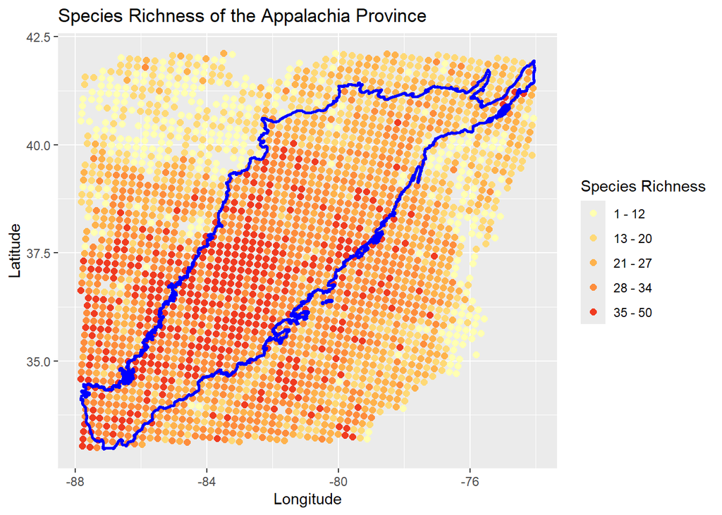

```r
ggplot() +
  geom_point(data = species_rich_class, aes(x = LON, y = LAT, color = JenksClass), size = 2) +
  scale_color_manual(values = c("#ffffb2","#fed976","#feb24c","#fd8d3c","#f03b20","#bd0026"), name = "Species Richness")+
  geom_point(data = fin_appalachia, aes(x = LON, y = LAT), size = 0.5, color = "blue") +
  labs(title = "Species Richness of the Appalachia Province",
       x = "Longitude",
       y = "Latitude" )
```

# Rapoport Effect:

To calculate the Rapoport Index for a given tree species you need both the latitudinal range & latitudinal midpoint of that species habitat.

```r
red_maple <- tree %>%
  filter(COMMON_NAME == "red maple")
latitude_values <- red_maple$LAT
longitude_values <- red_maple$LON

lat_analysis <- latitude_values
lat_range <- range(latitude_values, na.rm = TRUE)
lat_min <- min(latitude_values, na.rm = TRUE)
lat_max <- max(latitude_values, na.rm = TRUE)
lat_midpoint <- (lat_min + lat_max) / 2
latitudinal_range <- lat_range[2] - lat_range[1]

lon_range <- range(longitude_values, na.rm = TRUE)
lon_min <- min(longitude_values, na.rm = TRUE)
lon_max <- max(longitude_values, na.rm = TRUE)
lon_midpoint <- (lon_min + lon_max) / 2

red_maple_center <- c(LAT = lat_midpoint, LON = lon_midpoint)
red_maple_center <- as.data.frame(red_maple_center)
red_maple_center <- red_maple_center %>%
  mutate(
    LAT = lat_midpoint,
    LON = lon_midpoint
  )
```

### Rapoport Index Function:

```r
find_midpoint <- function(species_name, fia_data) {
  target_species <- tree %>%
    filter(COMMON_NAME == species_name)

  if (nrow(target_species) == 0) {
    return(data.frame(Species = species_name, Latitude_Midpoint = NA, Longitude_Midpoint = NA, Rapoport_Index = NA))
  }

  target_lat_values <- target_species$LAT
  target_lon_values <- target_species$LON

  target_lat_values <- target_lat_values[!is.na(target_lat_values)]
  target_lon_values <- target_lon_values[!is.na(target_lon_values)]

  if (length(target_lat_values) == 0 | length(target_lon_values) == 0) {
    return(data.frame(Species = species_name, Latitude_Midpoint = NA, Longitude_Midpoint = NA, Rapoport_Index = NA))
  }

  lat_min <- min(target_lat_values, na.rm = TRUE)
  lat_max <- max(target_lat_values, na.rm = TRUE)
  lon_min <- min(target_lon_values, na.rm = TRUE)
  lon_max <- max(target_lon_values, na.rm = TRUE)

  target_lat_midpoint <- (lat_min + lat_max) / 2
  target_lon_midpoint <- (lon_min + lon_max) / 2

  lat_range <- lat_max - lat_min

  Rapoport_Index <- lat_range / target_lat_midpoint

  midpoint_df <- data.frame(
    Species = species_name,
    LAT_midpoint = target_lat_midpoint,
    LON_midpoint = target_lon_midpoint,
    Rapoport_Index = Rapoport_Index
  )

}

tree_list <- unique(na.omit(tree$COMMON_NAME))
species_midpoints_list <- lapply(tree_list, function(species) find_midpoint(species, fia_data))
midpoints_df <- bind_rows(species_midpoints_list)
datatable(midpoints_df)
```

|  | Species | LAT_midpoint | LON_midpoint | Rapoport_Index |
| --- | --- | --- | --- | --- |
| 1 | boxelder | 38.80832 | -82.466905 | 0.5214881757313895 |
| 2 | baldcypress | 32.81618 | -84.8548506533448 | 0.4192261256489938 |
| 3 | American sycamore | 36.6405600738282 | -84.26546271205885 | 0.3687397217820693 |
| 4 | American elm | 38.16106 | -82.17432 | 0.5819120328418549 |
| 5 | red maple | 37.241735 | -81.384875 | 0.6085245491382182 |
| 6 | water hickory | 31.745395 | -85.777995 | 0.2953199983808675 |
| 7 | common persimmon | 33.12881 | -84.795575 | 0.43910179689521 |
| 8 | green ash | 37.505805 | -82.26482999999999 | 0.6090553182367369 |
| 9 | sweetgum | 34.41234 | -84.11336636327741 | 0.4088324130239326 |
| 10 | sugarberry | 33.71203 | -85.856925 | 0.4216453295752289 |

[output cut: 275 more lines]

```r
midpoints_df_clipped <- midpoints_df %>%
  filter(LON_midpoint >= -89.5 & LON_midpoint <= -73) %>%
  filter(LAT_midpoint >= 32.5 & LAT_midpoint <= 42.5)
```

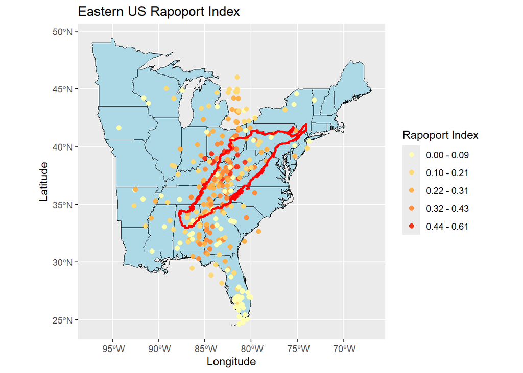

```r
rapoport_classes <- classIntervals(midpoints_df_clipped$Rapoport_Index, n = 5, style = "jenks")
rap_classes <- midpoints_df_clipped %>%
  mutate(JenksClass = cut(Rapoport_Index, breaks = rapoport_classes$brks, labels = 1:5, include.lowest = TRUE))
rap_all <- classIntervals(midpoints_df$Rapoport_Index, n = 5, style = "jenks")
rap_all_class <- midpoints_df %>%
  mutate(JenksClass = cut(Rapoport_Index, breaks = rap_all$brks, labels = 1:5, include.lowest = TRUE))
Index_label <- c("0.00 - 0.09", "0.10 - 0.21","0.22 - 0.31","0.32 - 0.43","0.44 - 0.61")
rap_all_class$JenksClass <- Index_label[rap_all_class$JenksClass]

usa <- ne_states(country = "United States of America", returnclass = "sf")
usa31 <- usa %>%
  filter(longitude >= -95 & longitude <= -65)

ggplot() +
  geom_sf(data = usa31, fill = "lightblue", color = "black") +
  geom_point(data = rap_all_class, aes(x = LON_midpoint, y = LAT_midpoint, color = JenksClass), size = 2) +
  geom_point(data = fin_appalachia, aes(x = LON, y = LAT), size = 0.5, color = "red") +
  scale_color_manual(values = c("#ffffb2","#fed976","#feb24c","#fd8d3c","#f03b20","#bd0026"), name = "Rapoport Index") +
  labs(title = "Eastern US Rapoport Index",
       x = "Longitude",
       y = "Latitude")
```

# Final Map :

Now that the Rapoport Index is calculated and I have isolated my study area to just the Appalachia Province, I can map them together:

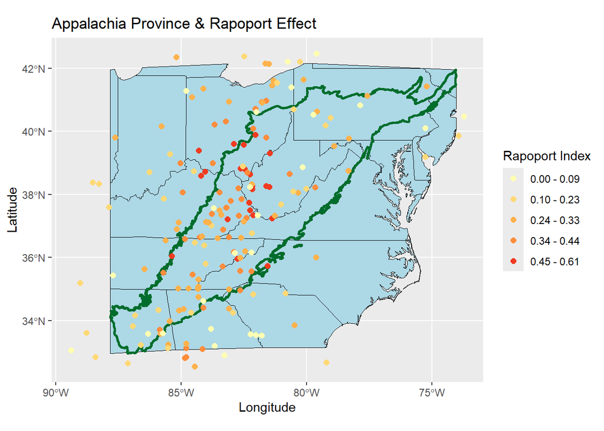

```r
usa31_sf <- st_as_sf(usa31, coords = c("longitude","latitude"), crs = 4326)
states_bbox <- st_crop(usa31_sf, bbox)

Clipped_label <- c("0.00 - 0.09", "0.10 - 0.23", "0.24 - 0.33", "0.34 - 0.44", "0.45 - 0.61")
rap_classes$JenksClass <- Clipped_label[rap_classes$JenksClass]

ggplot()+
  geom_sf(data = states_bbox, fill = "lightblue", color = "black") +
  geom_point(data = fin_appalachia, aes(x = LON, y = LAT), size = 0.5, color = "#006d2c") +
  geom_point(data = rap_classes, aes(x = LON_midpoint, y = LAT_midpoint, color = JenksClass), size = 2) +
  scale_color_manual(values = c("#ffffb2","#fed976","#feb24c","#fd8d3c","#f03b20","#bd0026"), name = "Rapoport Index") +
  labs(title = "Appalachia Province & Rapoport Effect",
       x = "Longitude",
       y = "Latitude")
```

# Extra

I’ve also added the graph of Latitudinal Midpoint compared to Rapoport Index: This graph looks very different from what I showed in class because my Rapoport Index was displaying the minimum & maximum Rapoport values for each species. This table shows singular Rapoport Index values for each species. I believe the odd shape is because I lack data north of the United States.

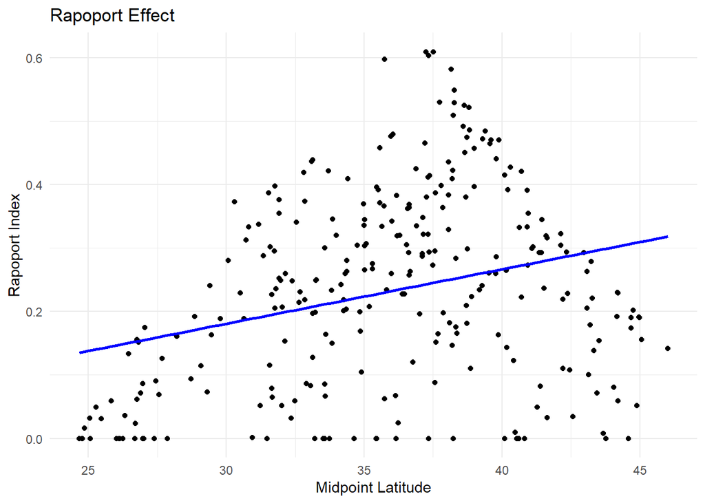

```r
ggplot(midpoints_df, aes(x = LAT_midpoint, y = Rapoport_Index)) +
  geom_point() +
  geom_smooth(method = "lm", se = FALSE, color = "blue") +
  labs(title = "Rapoport Effect",
       x = "Midpoint Latitude",
       y = "Rapoport Index") +
  theme_minimal()
```